# Written_homework_final_draft_comp

Jeffrey Ochavillo

2023-05-01

```r
library(tidyverse)
library(e1071)
library(ISLR2)
library(tidyverse)
library(ISLR2)
library(tree)
library(randomForest)
library(dplyr)
library(gbm)
library(dplyr)
library(haven)
```

```r
load("/Users/jeffreyochavillo/DATA 5322/written_homework2/Housing.Rdata")
```

```r
data1 <- data
```

```r
variables <- c('OWNERSHP','INCTOT','AGE','MARST','EDUC','EDUCD','VEHICLES','BEDROOMS')
peoplefactors <- data[,variables]
dim(peoplefactors)
```

```
## [1] 75388     8
```

```r
head(peoplefactors)
```

```
## # A tibble: 6 × 8
##   OWNERSHP             INCTOT AGE   MARST   EDUC     EDUCD     VEHICLES BEDROOMS
##   <int+lbl>            <dbl+> <int> <int+l> <int+lb> <int+lbl> <int+lb> <int+lb>
## 1 1 [Owned or being b… 75000  52    6 [Nev…  7 [1 y…  71 [1 o… 2        4 [3]
## 2 2 [Rented]            5600  22    6 [Nev… 10 [4 y… 101 [Bac… 2        4 [3]
## 3 2 [Rented]            8000  22    6 [Nev…  7 [1 y…  71 [1 o… 2        4 [3]
## 4 1 [Owned or being b…  7000  62    4 [Div…  6 [Gra…  63 [Reg… 2        4 [3]
## 5 2 [Rented]           16000  50    3 [Sep…  7 [1 y…  71 [1 o… 2        3 [2]
## 6 2 [Rented]           34500  18    6 [Nev…  6 [Gra…  61 [12t… 2        3 [2]
```

Your task is to predict, based on factors about the people or housing itself, if a dwelling is occupied by owners or renters

is housing/shelter is occupied by owners or renters So I need OWNERSHP,

```r
#need to filter the data where it's only containing values from those who can actually rent or own a home
#EDUCATION (7 - 11)
#AGE be greater than 18

clean_pf <- peoplefactors %>%
  filter(AGE >= 18) %>%
  filter(EDUC >= 7) %>%
  filter(EDUCD >= 62)

clean_pf
```

```
## # A tibble: 37,907 × 8
##    OWNERSHP            INCTOT AGE   MARST   EDUC     EDUCD     VEHICLES BEDROOMS
##    <int+lbl>           <dbl+> <int> <int+l> <int+lb> <int+lbl> <int+lb> <int+lb>
##  1 1 [Owned or being … 75000  52    6 [Nev…  7 [1 y…  71 [1 o… 2        4 [3]
##  2 2 [Rented]           5600  22    6 [Nev… 10 [4 y… 101 [Bac… 2        4 [3]
##  3 2 [Rented]           8000  22    6 [Nev…  7 [1 y…  71 [1 o… 2        4 [3]
##  4 2 [Rented]          16000  50    3 [Sep…  7 [1 y…  71 [1 o… 2        3 [2]
##  5 1 [Owned or being … 63000  80    1 [Mar… 10 [4 y… 101 [Bac… 2        4 [3]
##  6 1 [Owned or being … 89800  93    1 [Mar… 10 [4 y… 101 [Bac… 2        4 [3]
##  7 1 [Owned or being …  2500  52    6 [Nev… 10 [4 y… 101 [Bac… 2        4 [3]
##  8 1 [Owned or being … 65000  61    4 [Div… 10 [4 y… 101 [Bac… 3        5 [4 (1…
##  9 2 [Rented]          51300  45    6 [Nev…  8 [2 y…  81 [Ass… 1 [1 av… 3 [2]
## 10 2 [Rented]          12100  93    5 [Wid…  7 [1 y…  71 [1 o… 2        1 [No b…
## # ℹ 37,897 more rows
```

```r
data$AGE <- zap_labels(data$AGE)
data$AGE <- as.numeric(data$AGE)
data$INCTOT <- zap_labels(data$INCTOT)
data$INCTOT <- as.numeric(data$INCTOT)
data$MARST <- zap_labels(data$MARST)
data$MARST <- as.numeric(data$MARST)
data$EDUC <- zap_labels(data$EDUC)
data$EDUC <- as.numeric(data$EDUC)
data$OWNERSHPD <- zap_labels(data$OWNERSHPD)
data$OWNERSHPD <- as_factor(data$OWNERSHPD)
data$OWNERSHP <- zap_labels(data$OWNERSHP)
data$OWNERSHP <- as_factor(data$OWNERSHP)

#ADD THIS
data$EDUCD <- zap_labels(data$EDUCD)
data$EDUCD <- as.numeric(data$EDUCD)
data$VEHICLES <- zap_labels(data$VEHICLES)
data$VEHICLES <- as.numeric(data$VEHICLES)
```

```r
clean_pf$AGE <- zap_labels(clean_pf$AGE)
clean_pf$AGE <- as.numeric(clean_pf$AGE)
clean_pf$INCTOT <- zap_labels(clean_pf$INCTOT)
clean_pf$INCTOT <- as.numeric(clean_pf$INCTOT)
clean_pf$MARST <- zap_labels(clean_pf$MARST)
clean_pf$MARST <- as.numeric(clean_pf$MARST)
clean_pf$EDUC <- zap_labels(clean_pf$EDUC)
clean_pf$EDUC <- as.numeric(clean_pf$EDUC)
clean_pf$OWNERSHPD <- zap_labels(clean_pf$OWNERSHPD)
#clean_pf$OWNERSHPD <- as_factor(clean_pf$OWNERSHPD)
clean_pf$OWNERSHP <- zap_labels(clean_pf$OWNERSHP)
clean_pf$OWNERSHP <- as_factor(clean_pf$OWNERSHP)

#ADD THIS
clean_pf$EDUCD <- zap_labels(clean_pf$EDUCD)
clean_pf$EDUCD <- as.numeric(clean_pf$EDUCD)
clean_pf$VEHICLES <- zap_labels(clean_pf$VEHICLES)
clean_pf$VEHICLES <- as.numeric(clean_pf$VEHICLES)
clean_pf$BEDROOMS <- zap_labels(clean_pf$BEDROOMS)
clean_pf$BEDROOMS <- as.numeric(clean_pf$BEDROOMS)
```

```r
clean_pf_categories <- clean_pf %>%
  mutate(Education = case_when(EDUC == 7 ~ "1st Year of College",
                               EDUC == 8 ~ "2nd Year of College",
                               EDUC == 9 ~ "3rd Year of College",
                               EDUC == 10 ~ "4th Year of College",
                               EDUC == 11 ~ "5th Year of College")) %>%
  mutate(Marital_Status = case_when(MARST == 1 | MARST == 2 ~ "Married",
                               MARST == 3 | MARST == 4 ~ "Divorced",
                               MARST == 5 ~ "Single",
                               MARST == "NA" ~ "Other"))
```

one hot encoding FOR marital status

```r
encoded_data_marital_status <- clean_pf_categories  %>%
  mutate(Married  = case_when(MARST == 1 | MARST == 2 ~ "1",
                               MARST != 1 | MARST != 2 ~ "0")) %>%
  mutate(Single  = case_when(MARST == 5 ~ "1",
                             MARST != 5 ~ "0")) %>%
  mutate(Divorced  = case_when(MARST == 3 | MARST == 4 ~ "1",
                             MARST != 3 | MARST != 4 ~ "0"))
```

```r
encoded_data_marital_status2 <- encoded_data_marital_status

encoded_data_marital_status2 <- clean_pf_categories  %>%
  mutate(Marital_Status = case_when(MARST == 1 | MARST == 2 ~ "Married",
                             MARST == 3 | MARST == 4 ~ "Divorced",
                             MARST == 5 ~ "Single",
                             MARST == "NA" ~ "Other")) %>%
  mutate(OWNERSHP_Rented  = case_when(OWNERSHP == 2  ~ "1",
                               OWNERSHP != 2  ~ "0")) %>%
  mutate(OWNERSHP_Owned  = case_when(OWNERSHP == 1 ~ "1",
                             OWNERSHP != 1 ~ "0")) %>%
  mutate(Fixed_Ownership  = case_when(OWNERSHP == 1 ~ "0", #so 0 means it's owned
                             OWNERSHP == 2 ~ "1")) %>% #so 1 means it's rented %>%
  mutate(Married  = case_when(MARST == 1 | MARST == 2 ~ "1",
                               MARST != 1 | MARST != 2 ~ "0")) %>%
  mutate(Single  = case_when(MARST == 5 ~ "1",
                             MARST != 5 ~ "0")) %>%
  mutate(Divorced  = case_when(MARST == 3 | MARST == 4 ~ "1",
                             MARST != 3 | MARST != 4 ~ "0")) #%>%
```

```r
final_data <- encoded_data_marital_status2
```

```r
#Filter final data

final_data <- final_data %>%
  select(-c(Marital_Status,EDUCD,EDUC,MARST,OWNERSHP, Education))

# final_data <- final_data %>%
#   select(-c(Education))
```

```r
glimpse(final_data)
```

```
## Rows: 37,907
## Columns: 10
## $ INCTOT          <dbl> 75000, 5600, 8000, 16000, 63000, 89800, 2500, 65000, 5…
## $ AGE             <dbl> 52, 22, 22, 50, 80, 93, 52, 61, 45, 93, 65, 23, 37, 41…
## $ VEHICLES        <dbl> 2, 2, 2, 2, 2, 2, 2, 3, 1, 2, 2, 1, 2, 2, 2, 2, 2, 2, …
## $ BEDROOMS        <dbl> 4, 4, 4, 3, 4, 4, 4, 5, 3, 1, 1, 4, 5, 5, 3, 3, 6, 6, …
## $ OWNERSHP_Rented <chr> "0", "1", "1", "1", "0", "0", "0", "0", "1", "1", "1",…
## $ OWNERSHP_Owned  <chr> "1", "0", "0", "0", "1", "1", "1", "1", "0", "0", "0",…
## $ Fixed_Ownership <chr> "0", "1", "1", "1", "0", "0", "0", "0", "1", "1", "1",…
## $ Married         <chr> "0", "0", "0", "0", "1", "1", "0", "0", "0", "0", "0",…
## $ Single          <chr> "0", "0", "0", "0", "0", "0", "0", "0", "0", "1", "0",…
## $ Divorced        <chr> "0", "0", "0", "1", "0", "0", "0", "1", "0", "0", "1",…
```

```r
final_data$VEHICLES <- as.factor(final_data$VEHICLES)
final_data$Fixed_Ownership <- as.factor(final_data$Fixed_Ownership)
final_data$Married <- as.factor(final_data$Married)
final_data$Single <- as.factor(final_data$Single)
# final_data$HighSchool <- as.factor(final_data$HighSchool)
# final_data$College <- as.factor(final_data$College)
#final_data$Single <- as.factor(final_data$Single)
# final_data$Add_College <- as.factor(final_data$Add_College)
final_data$BEDROOMS <- as.factor(final_data$BEDROOMS)
final_data$INCTOT <- as.factor(final_data$INCTOT)
final_data$AGE <- as.factor(final_data$AGE)
```

```r
final_data %>% drop_na()
```

```
## # A tibble: 37,907 × 10
##    INCTOT AGE   VEHICLES BEDROOMS OWNERSHP_Rented OWNERSHP_Owned Fixed_Ownership
##    <fct>  <fct> <fct>    <fct>    <chr>           <chr>          <fct>
##  1 75000  52    2        4        0               1              0
##  2 5600   22    2        4        1               0              1
##  3 8000   22    2        4        1               0              1
##  4 16000  50    2        3        1               0              1
##  5 63000  80    2        4        0               1              0
##  6 89800  93    2        4        0               1              0
##  7 2500   52    2        4        0               1              0
##  8 65000  61    3        5        0               1              0
##  9 51300  45    1        3        1               0              1
## 10 12100  93    2        1        1               0              1
## # ℹ 37,897 more rows
## # ℹ 3 more variables: Married <fct>, Single <fct>, Divorced <chr>
```

```r
#dim(final_data)

final_svm_draft <- final_data %>%
  select(c(INCTOT,AGE,BEDROOMS, VEHICLES,Fixed_Ownership,Married,Single,Divorced))

final_svm_draft %>% drop_na()
```

```
## # A tibble: 37,907 × 8
##    INCTOT AGE   BEDROOMS VEHICLES Fixed_Ownership Married Single Divorced
##    <fct>  <fct> <fct>    <fct>    <fct>           <fct>   <fct>  <chr>
##  1 75000  52    4        2        0               0       0      0
##  2 5600   22    4        2        1               0       0      0
##  3 8000   22    4        2        1               0       0      0
##  4 16000  50    3        2        1               0       0      1
##  5 63000  80    4        2        0               1       0      0
##  6 89800  93    4        2        0               1       0      0
##  7 2500   52    4        2        0               0       0      0
##  8 65000  61    5        3        0               0       0      1
##  9 51300  45    3        1        1               0       0      0
## 10 12100  93    1        2        1               0       1      0
## # ℹ 37,897 more rows
```

```r
#Train test split
train <- sample(1:nrow(final_svm_draft), 800)
train.set <- final_svm_draft[train,]
test.set <- final_svm_draft[-train,]
```

```r
# p <- ggplot(final_data, aes(x=INCTOT, y=Fixed_Ownership))
# p + geom_point(size=3) +theme(text=element_text(size=18))
#
# p <- ggplot(final_data, aes(x=INCTOT, y=Fixed_Ownership))
# p + geom_point(size=3) +theme(text=element_text(size=18))
```

Kernel = Linear

```r
final.svm.linear <- svm(Fixed_Ownership ~., data = train.set, kernel = "linear",
    cost = 0.01, scale = FALSE)
summary(final.svm.linear)
```

```
##
## Call:
## svm(formula = Fixed_Ownership ~ ., data = train.set, kernel = "linear",
##     cost = 0.01, scale = FALSE)
##
##
## Parameters:
##    SVM-Type:  C-classification
##  SVM-Kernel:  linear
##        cost:  0.01
##
## Number of Support Vectors:  400
##
##  ( 215 185 )
##
##
## Number of Classes:  2
##
## Levels:
##  0 1
```

```r
pred.train <- predict(final.svm.linear, train.set)
cat('\nTraining Error rate is:')
```

```
##
## Training Error rate is:
```

```r
1 - mean(pred.train == train.set$Fixed_Ownership)
```

```
## [1] 0.23125
```

```r
table(predict = pred.train, truth = train.set$Fixed_Ownership)
```

```
##        truth
## predict   0   1
##       0 615 185
##       1   0   0
```

Predict

```r
pred.test <- predict(final.svm.linear, test.set)
cat('\nTesting Error rate is:')
```

```
##
## Testing Error rate is:
```

```r
#Test err
1 - mean(pred.test == test.set$Fixed_Ownership)
```

```
## [1] 0.2307651
```

```r
table(predict = pred.test, truth = test.set$Fixed_Ownership)
```

```
##        truth
## predict     0     1
##       0 28544  8563
##       1     0     0
```

I noticed that after randomly including Bedrooms out of pure interest, my results started to improve.

Tuning

```r
set.seed(1)
tune.out <- tune(svm, Fixed_Ownership ~ ., data = train.set, kernel = "linear",
    ranges = list(cost = c(0.01, 0.1, 1, 3, 5, 8, 10)))

bestmodel <- tune.out$best.model
summary(bestmodel)
```

```
##
## Call:
## best.tune(METHOD = svm, train.x = Fixed_Ownership ~ ., data = train.set,
##     ranges = list(cost = c(0.01, 0.1, 1, 3, 5, 8, 10)), kernel = "linear")
##
##
## Parameters:
##    SVM-Type:  C-classification
##  SVM-Kernel:  linear
##        cost:  0.1
##
## Number of Support Vectors:  374
##
##  ( 205 169 )
##
##
## Number of Classes:  2
##
## Levels:
##  0 1
```

```r
final.svm.linear.tuned <- svm(Fixed_Ownership ~ ., data = train.set, kernel = "linear",
    cost = 1, scale = FALSE)

pred.train <- predict(final.svm.linear.tuned, train.set)
cat('\nTraining Error rate is:')
```

```
##
## Training Error rate is:
```

```r
1 - mean(pred.train == train.set$Fixed_Ownership)
```

```
## [1] 0.085
```

```r
table(predict = pred.train, truth = train.set$Fixed_Ownership)
```

```
##        truth
## predict   0   1
##       0 599  52
##       1  16 133
```

```r
pred.test <- predict(final.svm.linear.tuned, test.set)
cat('\nTesting Error rate is:')
```

```
##
## Testing Error rate is:
```

```r
1 - mean(pred.test == test.set$Fixed_Ownership)
```

```
## [1] 0.1792115
```

```r
table(predict = pred.test, truth = test.set$Fixed_Ownership)
```

```
##        truth
## predict     0     1
##       0 26240  4346
##       1  2304  4217
```

```r
final.svm.linear.tuned.confm <- table(predict = pred.test, truth = test.set$Fixed_Ownership)
```

```r
library(yardstick)
```

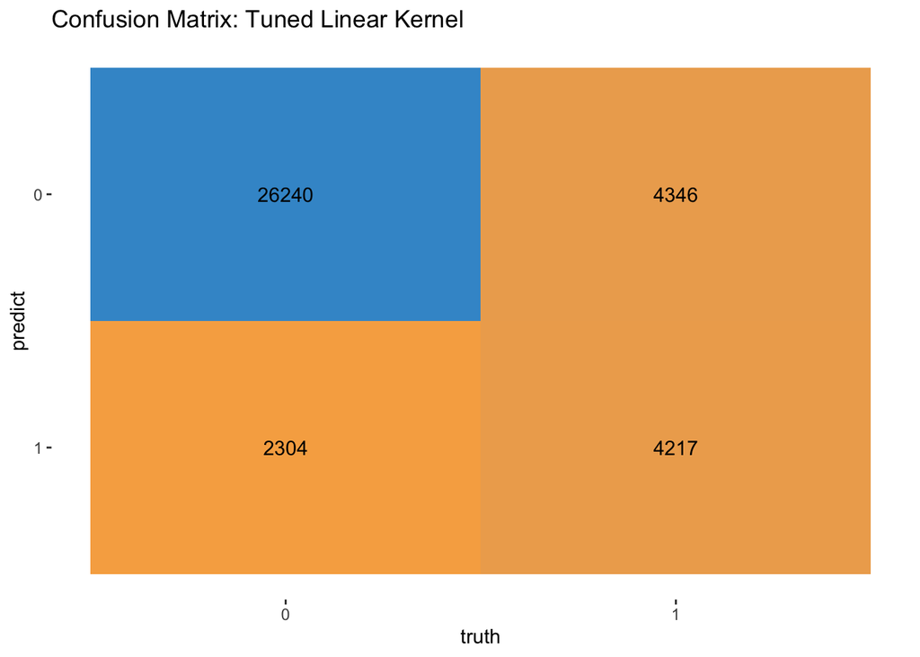

```r
library(ggplot2)


# The confusion matrix from a single assessment set (i.e. fold)
cm.linear <- conf_mat(final.svm.linear.tuned.confm, obs, pred)

autoplot(cm.linear, type = "heatmap") +
  scale_fill_gradient(low="#F7AD50",high = "#3F97D0") +
  ggtitle("Confusion Matrix: Tuned Linear Kernel")
```

Kernel set to Radial

```r
final.svm.radial <- svm(Fixed_Ownership ~ ., data = train.set, kernel = "radial",
    cost = 0.01, scale = FALSE)
summary(final.svm.radial)
```

```
##
## Call:
## svm(formula = Fixed_Ownership ~ ., data = train.set, kernel = "radial",
##     cost = 0.01, scale = FALSE)
##
##
## Parameters:
##    SVM-Type:  C-classification
##  SVM-Kernel:  radial
##        cost:  0.01
##
## Number of Support Vectors:  370
##
##  ( 185 185 )
##
##
## Number of Classes:  2
##
## Levels:
##  0 1
```

Radial train/testing

```r
pred.train <- predict(final.svm.radial, train.set)
cat('\nTrain Error Rate:')
```

```
##
## Train Error Rate:
```

```r
1 - mean(pred.train == train.set$Fixed_Ownership)
```

```
## [1] 0.23125
```

```r
table(predict = pred.train, truth = train.set$Fixed_Ownership)
```

```
##        truth
## predict   0   1
##       0 615 185
##       1   0   0
```

```r
pred.test <- predict(final.svm.radial, test.set)
cat('\nTesting Error rate is:')
```

```
##
## Testing Error rate is:
```

```r
1 - mean(pred.test == test.set$Fixed_Ownership)
```

```
## [1] 0.2307651
```

```r
table(predict = pred.test, truth = test.set$Fixed_Ownership)
```

```
##        truth
## predict     0     1
##       0 28544  8563
##       1     0     0
```

tuning radial

```r
#set.seed(1)
tune.out <- tune(svm, Fixed_Ownership ~ ., data = train.set, kernel = "radial",
    ranges = list(cost = c(0.01, 0.1, 10, 25, 50),
                  gamma = c(0.5, 1, 2, 3, 4)))
summary(tune.out)
```

```
##
## Parameter tuning of 'svm':
##
## - sampling method: 10-fold cross validation
##
## - best parameters:
##  cost gamma
##    10   0.5
##
## - best performance: 0.17625
##
## - Detailed performance results:
##     cost gamma   error dispersion
## 1   0.01   0.5 0.23125 0.05145454
## 2   0.10   0.5 0.23125 0.05145454
## 3  10.00   0.5 0.17625 0.05152197
## 4  25.00   0.5 0.17625 0.05152197
## 5  50.00   0.5 0.17625 0.05152197
## 6   0.01   1.0 0.23125 0.05145454
## 7   0.10   1.0 0.23125 0.05145454
## 8  10.00   1.0 0.21250 0.05303301
## 9  25.00   1.0 0.21250 0.05303301
## 10 50.00   1.0 0.21250 0.05303301
## 11  0.01   2.0 0.23125 0.05145454
## 12  0.10   2.0 0.23125 0.05145454
## 13 10.00   2.0 0.22875 0.05104804
## 14 25.00   2.0 0.22875 0.05104804
## 15 50.00   2.0 0.22875 0.05104804
## 16  0.01   3.0 0.23125 0.05145454
## 17  0.10   3.0 0.23125 0.05145454
## 18 10.00   3.0 0.22875 0.05104804
## 19 25.00   3.0 0.22875 0.05104804
## 20 50.00   3.0 0.22875 0.05104804
## 21  0.01   4.0 0.23125 0.05145454
## 22  0.10   4.0 0.23125 0.05145454
## 23 10.00   4.0 0.22875 0.05104804
## 24 25.00   4.0 0.22875 0.05104804
## 25 50.00   4.0 0.22875 0.05104804
```

```r
bestmodel <- tune.out$best.model
summary(bestmodel)
```

```
##
## Call:
## best.tune(METHOD = svm, train.x = Fixed_Ownership ~ ., data = train.set,
##     ranges = list(cost = c(0.01, 0.1, 10, 25, 50), gamma = c(0.5,
##         1, 2, 3, 4)), kernel = "radial")
##
##
## Parameters:
##    SVM-Type:  C-classification
##  SVM-Kernel:  radial
##        cost:  10
##
## Number of Support Vectors:  732
##
##  ( 550 182 )
##
##
## Number of Classes:  2
##
## Levels:
##  0 1
```

PLUG OUR VALUES in, cost = 10, gamma = 0.5

```r
final.svm.radial.tuned <- svm(Fixed_Ownership ~ ., data = train.set, kernel = 'radial',
             cost = 10, gamma = 0.5, scale = FALSE)

#Predict Train
pred.train <- predict(final.svm.radial.tuned, train.set)
cat('\nTraining Error rate is:')
```

```
##
## Training Error rate is:
```

```r
1 - mean(pred.train == train.set$Fixed_Ownership)
```

```
## [1] 0
```

```r
table(predict = pred.train, truth = train.set$Fixed_Ownership)
```

```
##        truth
## predict   0   1
##       0 615   0
##       1   0 185
```

```r
#Predict Test
pred.test <- predict(final.svm.radial.tuned, test.set)
cat('\nTesting Error rate is:')
```

```
##
## Testing Error rate is:
```

```r
1 - mean(pred.test == test.set$Fixed_Ownership)
```

```
## [1] 0.1678659
```

```r
table(predict = pred.test, truth = test.set$Fixed_Ownership)
```

```
##        truth
## predict     0     1
##       0 27127  4812
##       1  1417  3751
```

```r
final.svm.radial.tuned.confm <- table(predict = pred.test, truth = test.set$Fixed_Ownership)
```

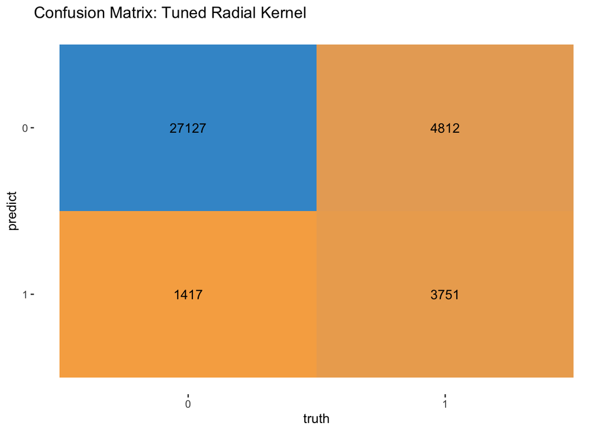

```r
library(yardstick)
library(ggplot2)


# The confusion matrix from a single assessment set (i.e. fold)
cm.radial <- conf_mat(final.svm.radial.tuned.confm, obs, pred)

autoplot(cm.radial, type = "heatmap") +
  scale_fill_gradient(low="#F7AD50",high = "#3F97D0") +
  ggtitle("Confusion Matrix: Tuned Radial Kernel")
```

Polynomial Kernel

```r
final.svm.poly <- svm(Fixed_Ownership ~ ., data = train.set, kernel = "polynomial",
    cost = 1, degree = 2, scale = FALSE)
summary(final.svm.poly)
```

```
##
## Call:
## svm(formula = Fixed_Ownership ~ ., data = train.set, kernel = "polynomial",
##     cost = 1, degree = 2, scale = FALSE)
##
##
## Parameters:
##    SVM-Type:  C-classification
##  SVM-Kernel:  polynomial
##        cost:  1
##      degree:  2
##      coef.0:  0
##
## Number of Support Vectors:  370
##
##  ( 185 185 )
##
##
## Number of Classes:  2
##
## Levels:
##  0 1
```

```r
pred.train <- predict(final.svm.poly, train.set)
cat('\nTrain Error Rate:')
```

```
##
## Train Error Rate:
```

```r
1 - mean(pred.train == train.set$Fixed_Ownership)
```

```
## [1] 0.23125
```

```r
table(predict = pred.train, truth = train.set$Fixed_Ownership)
```

```
##        truth
## predict   0   1
##       0 615 185
##       1   0   0
```

Predict Test Set - Polynomial kernel

```r
pred.test <- predict(final.svm.poly, test.set)
cat('\nTesting Error rate is:')
```

```
##
## Testing Error rate is:
```

```r
1 - mean(pred.test == test.set$Fixed_Ownership)
```

```
## [1] 0.2307651
```

```r
table(predict = pred.test, truth = test.set$Fixed_Ownership)
```

```
##        truth
## predict     0     1
##       0 28544  8563
##       1     0     0
```

tuning my polynomial kernel

```r
set.seed(1)
tune.out.poly <- tune(svm, Fixed_Ownership ~ ., data = train.set, kernel = "polynomial",
    ranges = list(cost = c(0.01, 0.1, 1, 10, 25),
                  degree = c(1, 2, 3, 4, 5)))
summary(tune.out.poly)
```

```
##
## Parameter tuning of 'svm':
##
## - sampling method: 10-fold cross validation
##
## - best parameters:
##  cost degree
##  0.01      1
##
## - best performance: 0.23125
##
## - Detailed performance results:
##     cost degree   error dispersion
## 1   0.01      1 0.23125 0.03019037
## 2   0.10      1 0.23125 0.03019037
## 3   1.00      1 0.23125 0.03019037
## 4  10.00      1 0.23125 0.03019037
## 5  25.00      1 0.23125 0.03019037
## 6   0.01      2 0.23125 0.03019037
## 7   0.10      2 0.23125 0.03019037
## 8   1.00      2 0.23125 0.03019037
## 9  10.00      2 0.23125 0.03019037
## 10 25.00      2 0.23125 0.03019037
## 11  0.01      3 0.23125 0.03019037
## 12  0.10      3 0.23125 0.03019037
## 13  1.00      3 0.23125 0.03019037
## 14 10.00      3 0.23125 0.03019037
## 15 25.00      3 0.23125 0.03019037
## 16  0.01      4 0.23125 0.03019037
## 17  0.10      4 0.23125 0.03019037
## 18  1.00      4 0.23125 0.03019037
## 19 10.00      4 0.23125 0.03019037
## 20 25.00      4 0.23125 0.03019037
## 21  0.01      5 0.23125 0.03019037
## 22  0.10      5 0.23125 0.03019037
## 23  1.00      5 0.23125 0.03019037
## 24 10.00      5 0.23125 0.03019037
## 25 25.00      5 0.23125 0.03019037
```

```r
bestmodel <- tune.out.poly$best.model
summary(bestmodel)
```

```
##
## Call:
## best.tune(METHOD = svm, train.x = Fixed_Ownership ~ ., data = train.set,
##     ranges = list(cost = c(0.01, 0.1, 1, 10, 25), degree = c(1, 2,
##         3, 4, 5)), kernel = "polynomial")
##
##
## Parameters:
##    SVM-Type:  C-classification
##  SVM-Kernel:  polynomial
##        cost:  0.01
##      degree:  1
##      coef.0:  0
##
## Number of Support Vectors:  370
##
##  ( 185 185 )
##
##
## Number of Classes:  2
##
## Levels:
##  0 1
```

Now fit and predict using returned parameter cost = 0.01, degree = 1

```r
final.svm.poly.tuned <- svm(Fixed_Ownership ~ ., data = train.set, kernel = 'polynomial',
             cost = 0.01, degree = 1, scale = FALSE)

#Predict Train
pred.train <- predict(final.svm.poly.tuned, train.set)
cat('\nTraining Error rate is:')
```

```
##
## Training Error rate is:
```

```r
1 - mean(pred.train == train.set$Fixed_Ownership)
```

```
## [1] 0.23125
```

```r
table(predict = pred.train, truth = train.set$Fixed_Ownership)
```

```
##        truth
## predict   0   1
##       0 615 185
##       1   0   0
```

```r
#Predict Test
pred.test <- predict(final.svm.poly.tuned, test.set)
cat('\nTesting Error rate is:')
```

```
##
## Testing Error rate is:
```

```r
1 - mean(pred.test == test.set$Fixed_Ownership)
```

```
## [1] 0.2307651
```

```r
table(predict = pred.test, truth = test.set$Fixed_Ownership)
```

```
##        truth
## predict     0     1
##       0 28544  8563
##       1     0     0
```

```r
final.svm.poly.tuned.confm <- table(predict = pred.test, truth = test.set$Fixed_Ownership)
```

Gets the confusion matrix for Poly Kernel

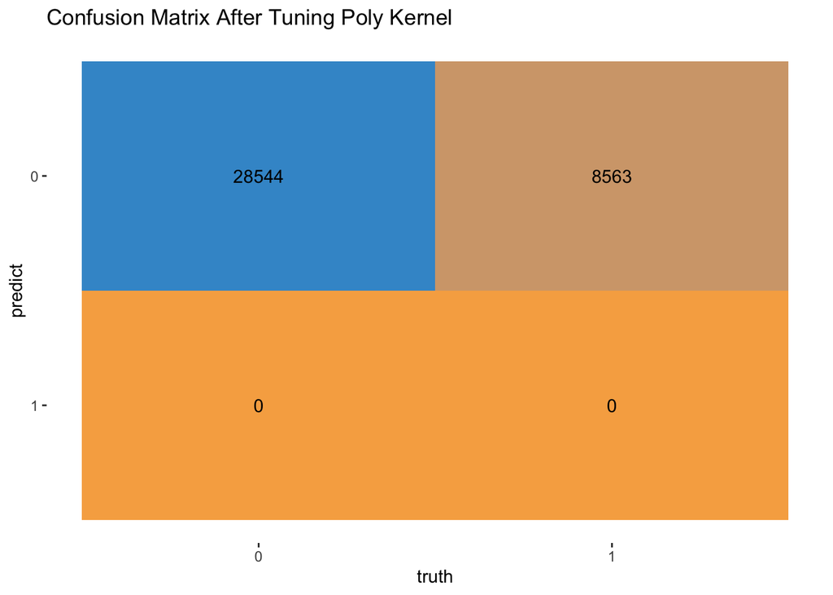

```r
library(yardstick)
library(ggplot2)


# The confusion matrix from a single assessment set (i.e. fold)
cm.poly <- conf_mat(final.svm.poly.tuned.confm, obs, pred)

autoplot(cm.poly, type = "heatmap") +
  scale_fill_gradient(low="#F7AD50",high = "#3F97D0") +
  ggtitle("Confusion Matrix After Tuning Poly Kernel ")
```

```r
svm_final <- svm(Fixed_Ownership ~., data = train.set, kernel = "linear",
    cost = 0.01, scale = FALSE)
summary(svm_final)
```

```
##
## Call:
## svm(formula = Fixed_Ownership ~ ., data = train.set, kernel = "linear",
##     cost = 0.01, scale = FALSE)
##
##
## Parameters:
##    SVM-Type:  C-classification
##  SVM-Kernel:  linear
##        cost:  0.01
##
## Number of Support Vectors:  400
##
##  ( 215 185 )
##
##
## Number of Classes:  2
##
## Levels:
##  0 1
```

```r
# #Let's take it a sample size of 5000
# df_sample <- df[sample(nrow(final_data), 2000), ]
#
# train <- sample(1:nrow(df_sample), nrow(df_sample) * 0.7)
# train.setg <- df_sample[train,]
# test.setg <- df_sample[-train,]
```

Compute the magnitude to get most significant variables

```r
# Train a linear SVM model with the final_data dataset

train.setg <- train.set
train.setg <- apply(train.setg, 2, as.numeric)


final.svm.linear.calc <- svm(Fixed_Ownership ~ ., data = train.setg, kernel = "linear")

# Get the coefficients for the linear SVM model
svm.coef <- coef(final.svm.linear.calc)

# Compute the magnitude of the coefficients
svm.coef.abs <- abs(svm.coef)

# Extract the top 3 input variables with the largest coefficient magnitudes
top.vars <- names(sort(svm.coef.abs, decreasing = TRUE)[1:8])
top.vars
```

```
## [1] "(Intercept)" "BEDROOMS"    "Married"     "Divorced"    "Single"
## [6] "AGE"         "VEHICLES"    "INCTOT"
```

final_svm_draft <- final_data %>% select(c(INCTOT,AGE, VEHICLES,Fixed_Ownership,Married,Single,Divorced))

final_svm_draft %>% drop_na()

#Train test split train <- sample(1:nrow(final_svm_draft), 800) train.set <- final_svm_draft[train,] test.set <- final_svm_draft[-train,]

Produces svm plot for INCTOT and Age

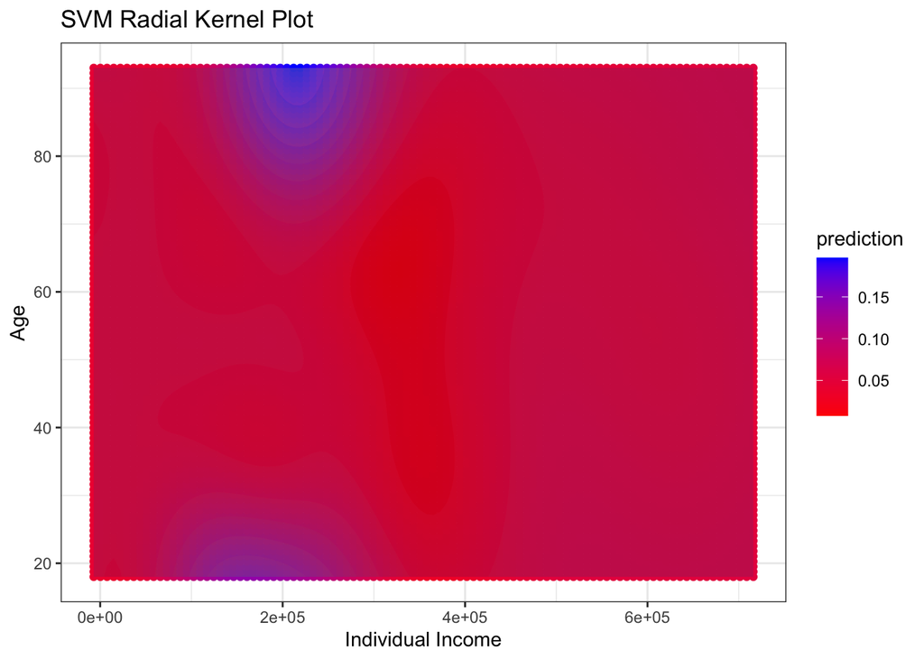

```r
# split data into train and test sets
train.setg1 <- as.data.frame(train.setg)

training <- sample(1:nrow(train.setg1), size = 400)
train.plot <- train.setg1[training, ]
test.plot <- train.setg1[-training, ]

# create radial kernel SVM model
svm_rad_plot <- svm(Fixed_Ownership ~ INCTOT + AGE, data = train.plot, kernel = "radial")

# plot SVM decision boundary
plot(svm_rad_plot, train.plot, INCTOT~AGE,
     main = 'SVM Radial Kernel Plot',
     xlab = 'INCTOT', ylab = 'AGE',
     width = 10, height = 10)

# create grid of values for prediction
ind_income_grid <- seq(min(train.setg1$INCTOT), max(train.setg1$INCTOT), length.out = 100)
age_income_grid <- seq(min(train.setg1$AGE), max(train.setg1$AGE), length.out = 100)
grid_data <- expand.grid(INCTOT = ind_income_grid, AGE = age_income_grid)
predicted_data <- predict(svm_rad_plot, newdata = grid_data)

# combine prediction with grid data
plot_data <- cbind(grid_data, prediction = predicted_data)

# create SVM plot
# create SVM plot
ggplot(data = plot_data, aes(x = INCTOT, y = AGE)) +
  geom_point(aes(color = prediction)) +
  scale_color_gradient(low = "red", high = "blue") +
  stat_contour_filled(aes(z = as.numeric(prediction)), alpha = 0.2) +
  labs(title = "SVM Radial Kernel Plot", x = "Individual Income", y = "Age") +
  theme_bw() + guides(fill = FALSE) #Remove Legends
```

Produces svm plot for INCTOT and Bedrooms

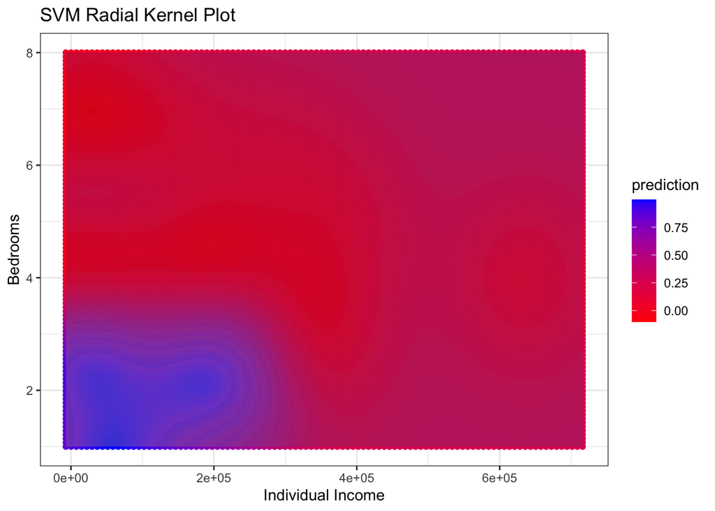

```r
# split data into train and test sets
train.setg1 <- as.data.frame(train.setg)

training <- sample(1:nrow(train.setg1), size = 400)
train.plot <- train.setg1[training, ]
test.plot <- train.setg1[-training, ]

# create radial kernel SVM model
svm_rad_plot <- svm(Fixed_Ownership ~ INCTOT + BEDROOMS, data = train.plot, kernel = "radial")

# plot SVM decision boundary
plot(svm_rad_plot, train.plot, INCTOT~AGE,
     main = 'SVM Radial Kernel Plot',
     xlab = 'INCTOT', ylab = 'BEDROOMS',
     width = 10, height = 10)

# create grid of values for prediction
ind_income_grid <- seq(min(train.setg1$INCTOT), max(train.setg1$INCTOT), length.out = 100)
bedrooms_grid <- seq(min(train.setg1$BEDROOMS), max(train.setg1$BEDROOMS), length.out = 100)
grid_data <- expand.grid(INCTOT = ind_income_grid, BEDROOMS = bedrooms_grid)
predicted_data <- predict(svm_rad_plot, newdata = grid_data)

# combine prediction with grid data
plot_data <- cbind(grid_data, prediction = predicted_data)

# create SVM plot
# create SVM plot
ggplot(data = plot_data, aes(x = INCTOT, y = BEDROOMS)) +
  geom_point(aes(color = prediction)) +
  scale_color_gradient(low = "red", high = "blue") +
  stat_contour_filled(aes(z = as.numeric(prediction)), alpha = 0.2) +
  labs(title = "SVM Radial Kernel Plot", x = "Individual Income", y = "Bedrooms") +
  theme_bw() + guides(fill = FALSE) #Remove Legends
```

Produces svm plot for Bedrooms and Age

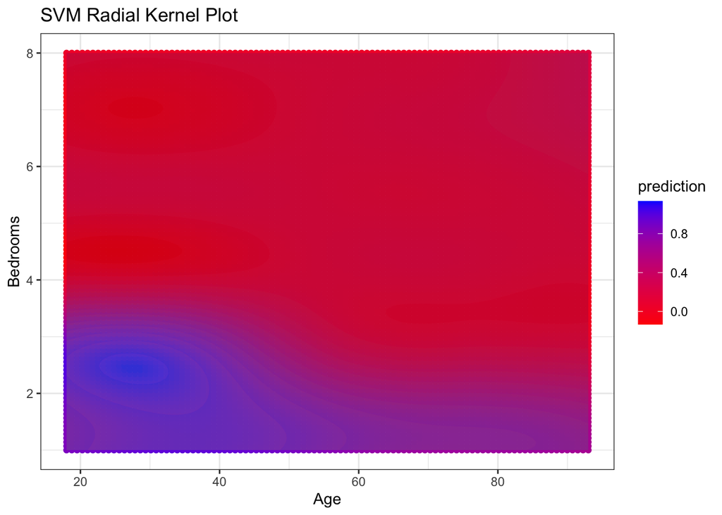

```r
# split data into train and test sets
train.setg1 <- as.data.frame(train.setg)

training <- sample(1:nrow(train.setg1), size = 400)
train.plot <- train.setg1[training, ]
test.plot <- train.setg1[-training, ]

# create radial kernel SVM model
svm_rad_plot <- svm(Fixed_Ownership ~ AGE + BEDROOMS, data = train.plot, kernel = "radial")

# plot SVM decision boundary
plot(svm_rad_plot, train.plot, AGE~BEDROOMS,
     main = 'SVM Radial Kernel Plot',
     xlab = 'AGE', ylab = 'BEDROOMS',
     width = 10, height = 10)

# create grid of values for prediction
age_grid <- seq(min(train.setg1$AGE), max(train.setg1$AGE), length.out = 100)
bedrooms_grid <- seq(min(train.setg1$BEDROOMS), max(train.setg1$BEDROOMS), length.out = 100)
grid_data <- expand.grid(AGE = age_grid, BEDROOMS = bedrooms_grid)
predicted_data <- predict(svm_rad_plot, newdata = grid_data)

# combine prediction with grid data
plot_data <- cbind(grid_data, prediction = predicted_data)

# create SVM plot
# create SVM plot
ggplot(data = plot_data, aes(x = AGE, y = BEDROOMS)) +
  geom_point(aes(color = prediction)) +
  scale_color_gradient(low = "red", high = "blue") +
  stat_contour_filled(aes(z = as.numeric(prediction)), alpha = 0.2) +
  labs(title = "SVM Radial Kernel Plot", x = "Age", y = "Bedrooms") +
  theme_bw() + guides(fill = FALSE) #Remove Legends
```

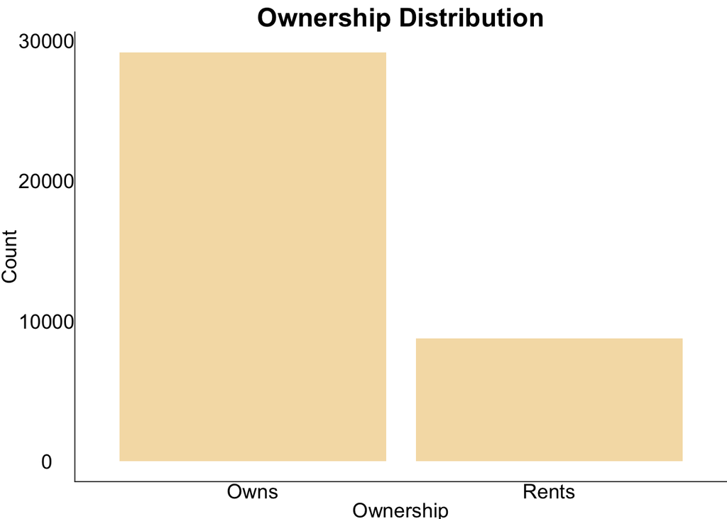

```r
ggplot(final_data, aes(x = Fixed_Ownership)) +
  geom_bar(fill = "#F5DEB3") +
  labs(x = "Ownership", y = "Count") +
  ggtitle("Ownership Distribution") +
  scale_fill_manual(values = c("owned" = "#F5DEB3", "rent" = "#F5DEB3")) +
  theme_void() +
  theme(plot.title = element_text(size = 18, face = "bold", hjust = 0.5),
        axis.title.x = element_text(size = 14),
        axis.title.y = element_text(size = 14, angle = 90),
        axis.text = element_text(size = 14),
        axis.line = element_line(color = "#2E2E2E")) +
  scale_x_discrete(labels = c("0" = "Owns", "1" = "Rents"))
```